# Data Preperation

We do the same for wave 6 (age 14):

```
##
## Variable: imp6_tem
```

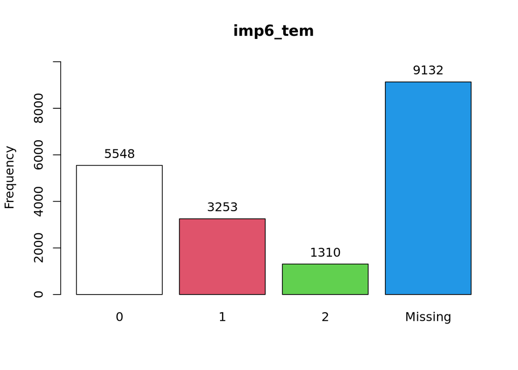

```
##
## Variable: imp6_res
```

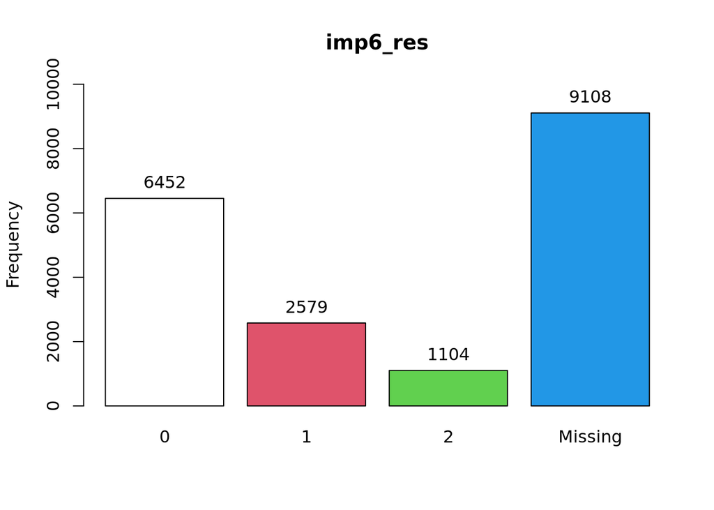

```
##
## Variable: imp6_fid
```

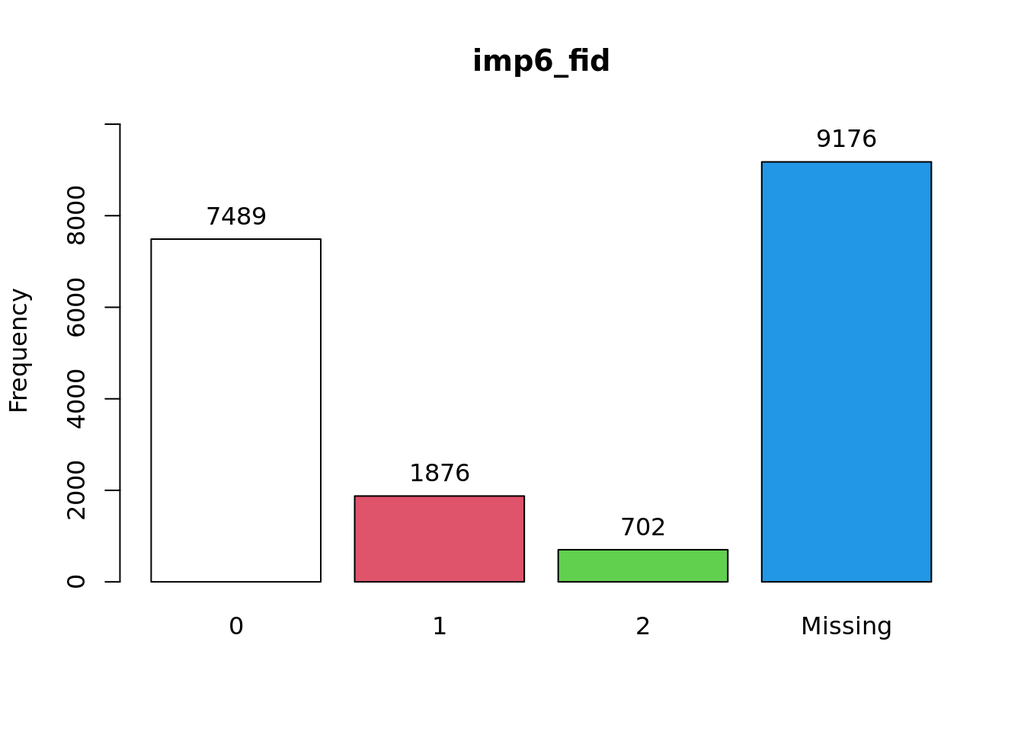

```
##
## Variable: imp6_dis
```

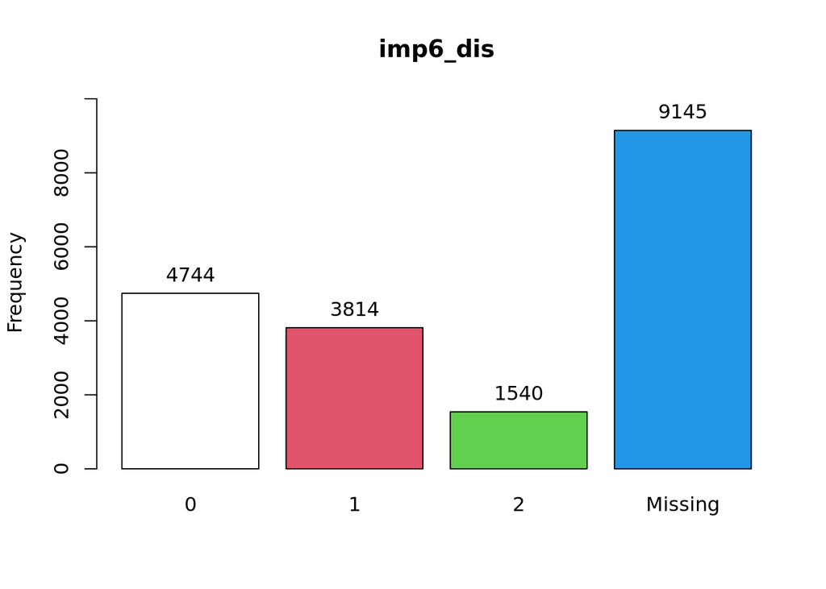

```
##
## Variable: imp6_thi
```

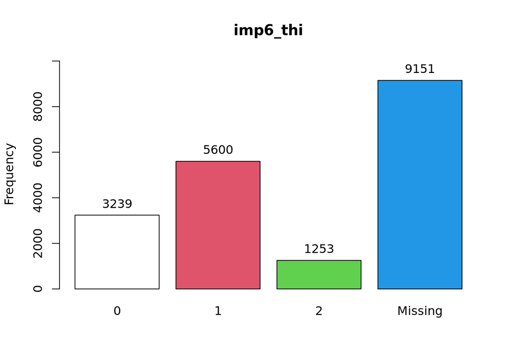

```
##
## Variable: imp6_tas
```

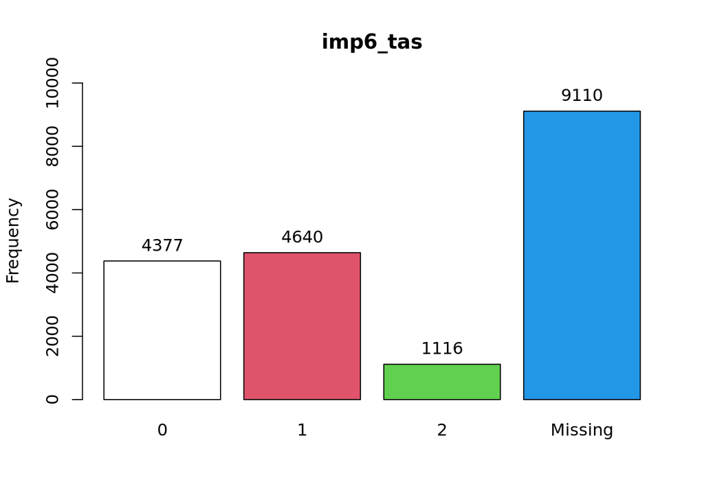

```
##
## Variable: risk6_lie
```

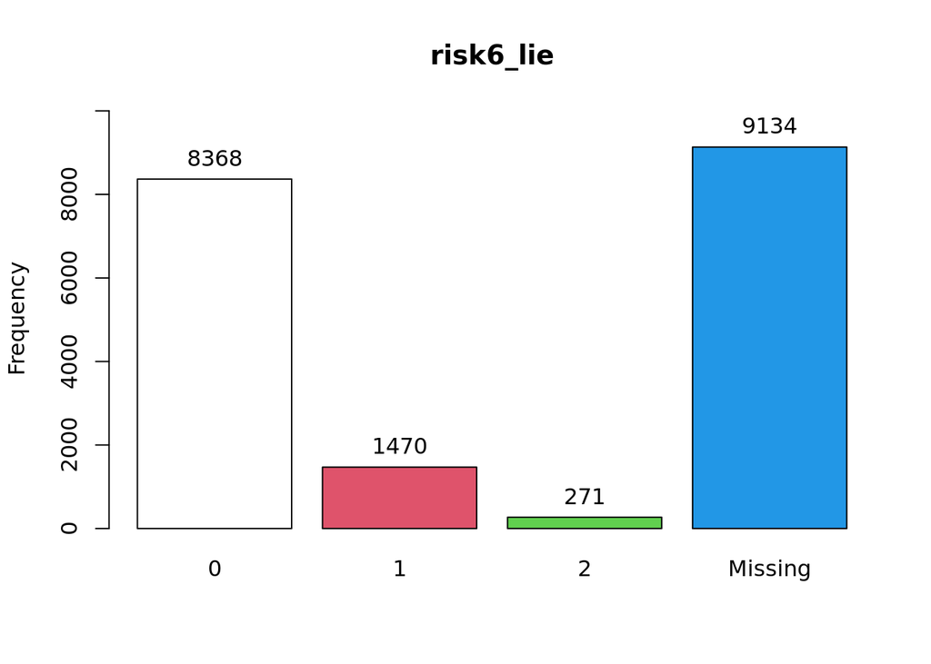

```
##
## Variable: risk6_ste
```

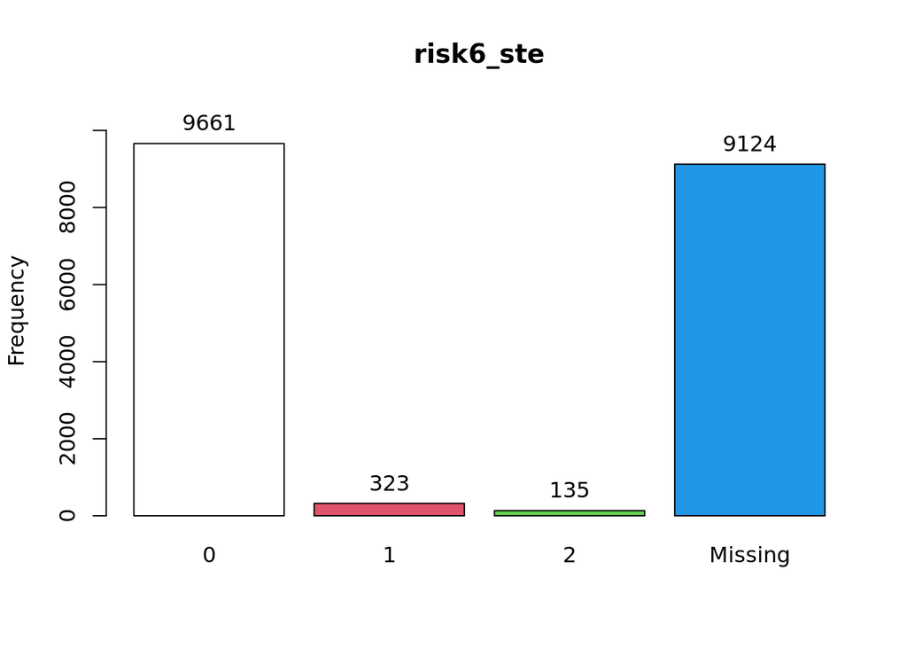

```
##
## Variable: risk6_obe
```

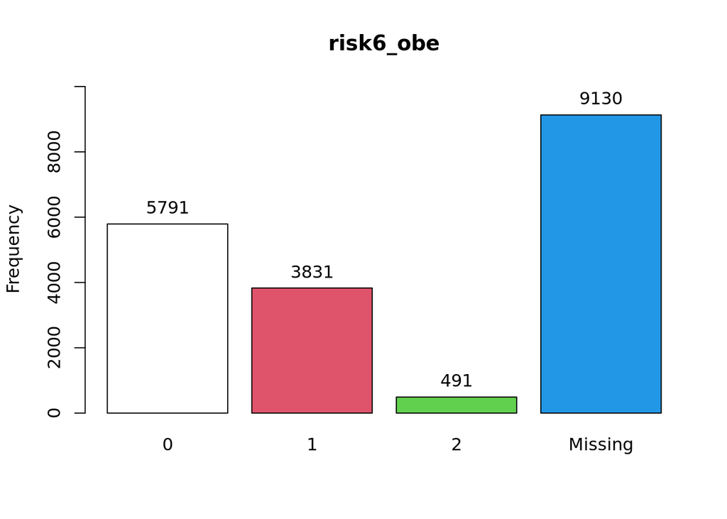

```
##
## Variable: risk6_shl
```

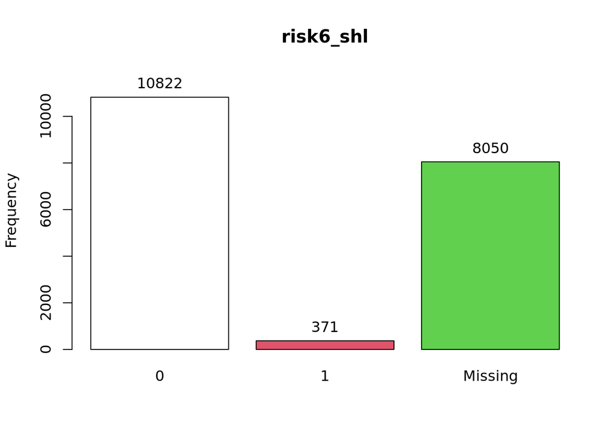

```
##
## Variable: risk6_wpp
```

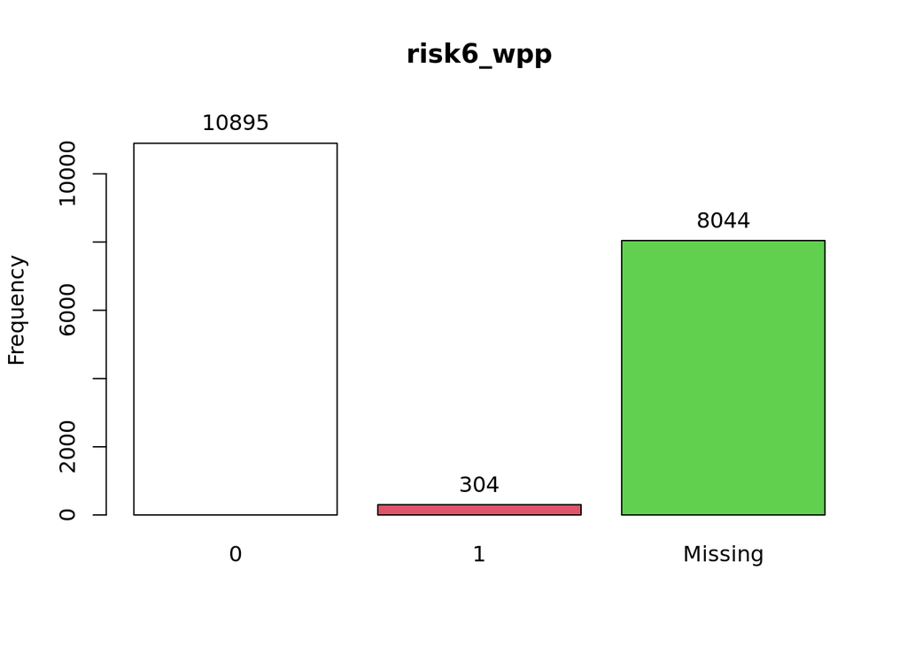

```
##
## Variable: risk6_smk
```

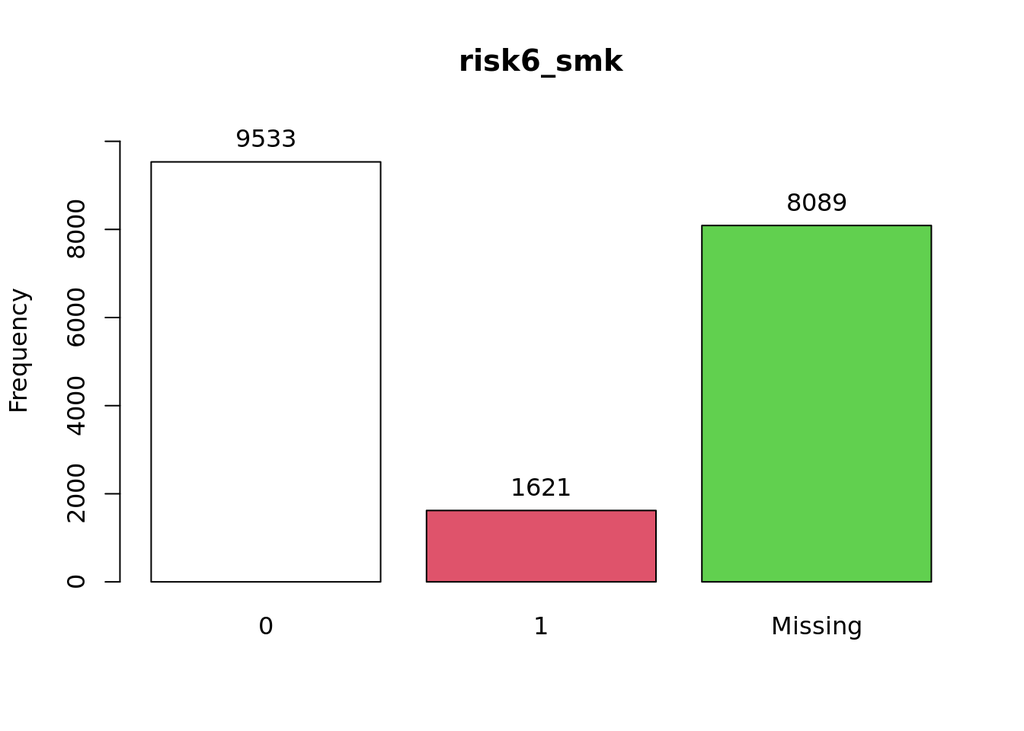

```
##
## Variable: risk6_drk
```

[3 more figures not shown]

```
## [[1]]
## df5[, var_name] :
##         Frequency   %(NA+)   %(NA-)
## 0            5548     28.8     54.9
## 1            3253     16.9     32.2
## 2            1310      6.8     13.0
## <NA>         9132     47.5      0.0
##   Total     19243    100.0    100.0
##
## [[2]]
## df5[, var_name] :
##         Frequency   %(NA+)   %(NA-)
## 0            6452     33.5     63.7
## 1            2579     13.4     25.4
## 2            1104      5.7     10.9
## <NA>         9108     47.3      0.0
##   Total     19243    100.0    100.0
##
## [[3]]
## df5[, var_name] :
##         Frequency   %(NA+)   %(NA-)
## 0            7489     38.9     74.4
## 1            1876      9.7     18.6
## 2             702      3.6      7.0
## <NA>         9176     47.7      0.0
##   Total     19243    100.0    100.0
##
## [[4]]
## df5[, var_name] :
##         Frequency   %(NA+)   %(NA-)
## 0            4744     24.7     47.0
## 1            3814     19.8     37.8
## 2            1540      8.0     15.3
## <NA>         9145     47.5      0.0
##   Total     19243    100.0    100.0
##
## [[5]]
## df5[, var_name] :
##         Frequency   %(NA+)   %(NA-)
## 0            3239     16.8     32.1
```

[output cut: 73 more lines]

```
## [[14]]
## df5[, var_name] :
##         Frequency   %(NA+)   %(NA-)
## 0            9725     50.5     86.9
## 1            1467      7.6     13.1
## <NA>         8051     41.8      0.0
##   Total     19243    100.0    100.0
##
## [[15]]
## df5[, var_name] :
##         Frequency   %(NA+)   %(NA-)
## 0           10848     56.4     96.9
## 1             346      1.8      3.1
## <NA>         8049     41.8      0.0
##   Total     19243    100.0    100.0
```

```r
df5 <- merged_data %>%
  mutate(
    # Self-Control Variables
    imp6_tem = case_when(
      fpsdtt00 %in% c(-9, -1) ~ NA_real_,
      fpsdtt00 == 1 ~ 0,
      fpsdtt00 == 2 ~ 1,
      fpsdtt00 == 3 ~ 2
    ),
    imp6_res = case_when(
      fpsdro00 %in% c(-9, -1) ~ NA_real_,
      fpsdro00 == 1 ~ 0,
      fpsdro00 == 2 ~ 1,
      fpsdro00 == 3 ~ 2
    ),
    imp6_fid = case_when(
      fpsdfs00 %in% c(-9, -1) ~ NA_real_,
      fpsdfs00 == 1 ~ 0,
      fpsdfs00 == 2 ~ 1,
      fpsdfs00 == 3 ~ 2
    ),
    imp6_dis = case_when(
      fpsddc00 %in% c(-9, -1) ~ NA_real_,
      fpsddc00 == 1 ~ 0,
      fpsddc00 == 2 ~ 1,
      fpsddc00 == 3 ~ 2
    ),
    imp6_thi = case_when(
      fpsdst00 %in% c(-9, -1) ~ NA_real_,
      fpsdst00 == 1 ~ 2,
      fpsdst00 == 2 ~ 1,
      fpsdst00 == 3 ~ 0
    ),
    imp6_tas = case_when(
      fpsdte00 %in% c(-9, -1) ~ NA_real_,
      fpsdte00 == 1 ~ 2,
      fpsdte00 == 2 ~ 1,
      fpsdte00 == 3 ~ 0
    ),
    # Risk Taking Variables
    risk6_lie = case_when(
      fpsdoa00 %in% c(-9, -1) ~ NA_real_,
      fpsdoa00 == 1 ~ 0,
      fpsdoa00 == 2 ~ 1,
      fpsdoa00 == 3 ~ 2
    ),
    risk6_ste = case_when(
      fpsdcs00 %in% c(-9, -1) ~ NA_real_,
      fpsdcs00 == 1 ~ 0,
      fpsdcs00 == 2 ~ 1,
      fpsdcs00 == 3 ~ 2
    ),
    risk6_obe = case_when(
      fpsdor00 %in% c(-9, -1) ~ NA_real_,
      fpsdor00 == 1 ~ 2,
      fpsdor00 == 2 ~ 1,
      fpsdor00 == 3 ~ 0
    ),
    risk6_shl = case_when(
      fcstol00 %in% c(-9, -8, -1) ~ NA_real_,
      fcstol00 == 2 ~ 0,
      fcstol00 == 1 ~ 1
    ),
    risk6_wpp = case_when(
      fcspry00 %in% c(-9, -8, -1) ~ NA_real_,
      fcspry00 == 2 ~ 0,
      fcspry00 == 1 ~ 1
    ),
    risk6_smk = case_when(
      fcsmok00 %in% c(-9, -8, -1) ~ NA_real_,
      fcsmok00 == 1 ~ 0,
      fcsmok00 %in% c(2, 3, 4, 5, 6) ~ 1
    ),
    risk6_drk = case_when(
      fcalcd00 %in% c(-9, -8, -1) ~ NA_real_,
      fcalcd00 == 2 ~ 0,
      fcalcd00 == 1 ~ 1
    ),
    risk6_rude = case_when(
      fcrude00 %in% c(-9, -8, -1) ~ NA_real_,
      fcrude00 == 2 ~ 0,
      fcrude00 == 1 ~ 1
    ),
    risk6_damg = case_when(
      fcdamg00 %in% c(-9, -8, -1) ~ NA_real_,
      fcdamg00 == 2 ~ 0,
      fcdamg00 == 1 ~ 1
    )
  ) %>%
   dplyr::select(imp6_tem, imp6_res, imp6_fid, imp6_dis, imp6_thi, imp6_tas, risk6_lie, risk6_ste, risk6_obe, risk6_shl, risk6_wpp, risk6_smk, risk6_drk, risk6_rude, risk6_damg) %>%
  labelled::set_variable_labels(
    imp6_tem = "Tempur Tantrums",
    imp6_res = "Restless",
    imp6_fid = "Fidgeting",
    imp6_dis = "Easily Distracted",
    imp6_thi = "Think Before Act (Reverse Scale)",
    imp6_tas = "Sees Task Through to the End (Reverse Scale)",
    risk6_lie = "Lie or Cheat",
    risk6_ste = "Steal",
    risk6_obe = "Generally Obedient (Reverse Scale)",
    risk6_shl = "Shoplifting",
    risk6_wpp = "Write/Paint in Public Places",
    risk6_smk = "Underage Smoking",
    risk6_drk = "Underage Drinking",
    risk6_rude = "Rude or Noisy in Public",
    risk6_damg = "Damage Something That Doesn't Belong to Them"
  )

# Show descriptive statistics
self_control6 <- c("imp6_tem", "imp6_res", "imp6_fid", "imp6_dis", "imp6_thi", "imp6_tas","risk6_lie", "risk6_ste", "risk6_obe", "risk6_shl", "risk6_wpp", "risk6_smk", "risk6_drk", "risk6_rude", "risk6_damg")

lapply(self_control6, function(var_name) {
  cat("\nVariable:", var_name, "\n")
  tab1(df5[, var_name], main = var_name)
})
```

Now we do the same for wave 5:

```
##
## Variable: imp5_tem
```

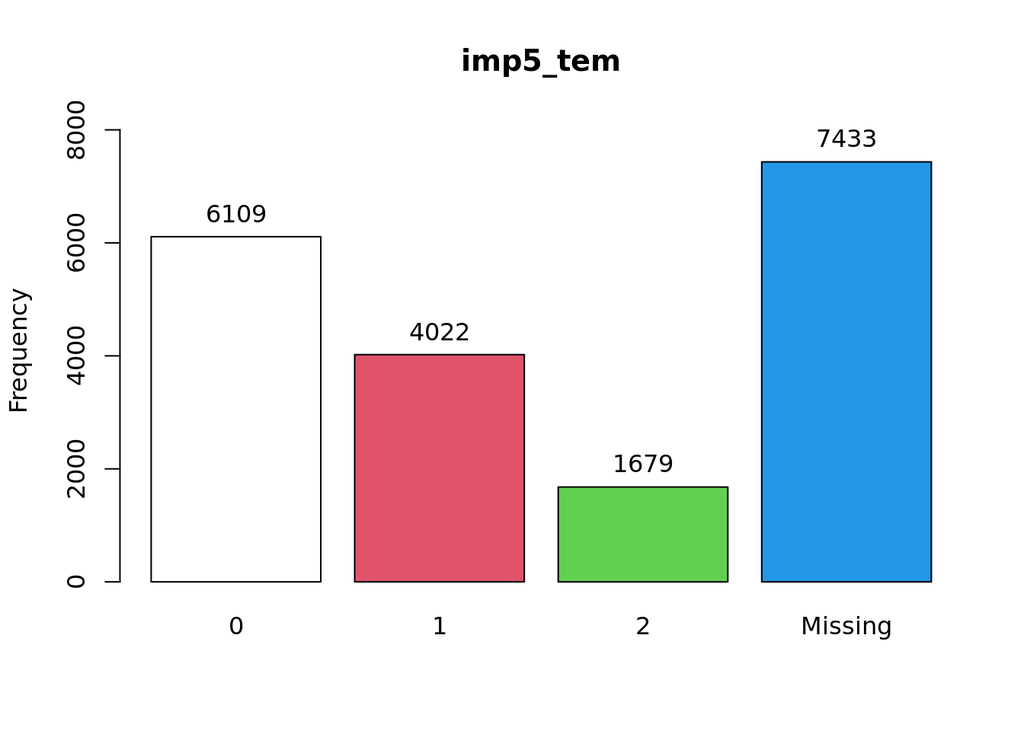

```
##
## Variable: imp5_res
```

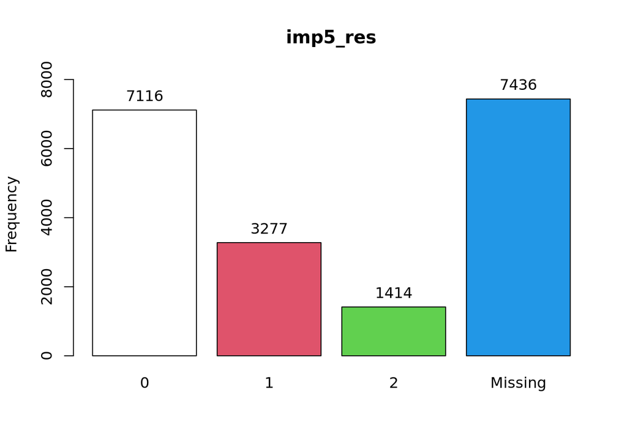

```
##
## Variable: imp5_fid
```

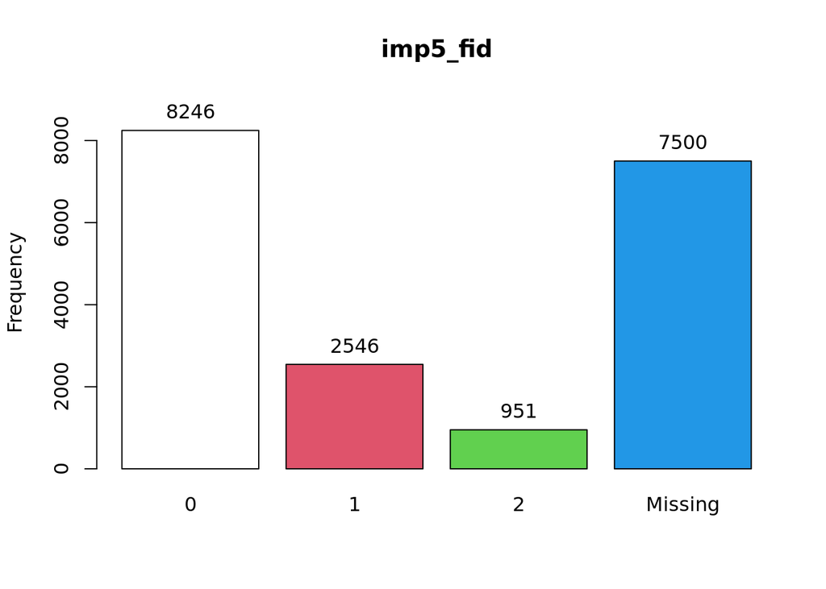

```
##
## Variable: imp5_dis
```

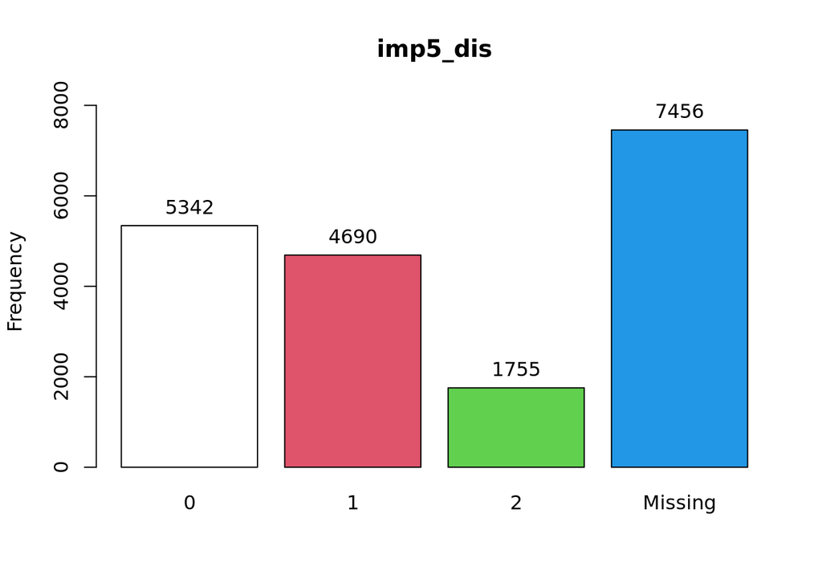

```
##
## Variable: imp5_thi
```

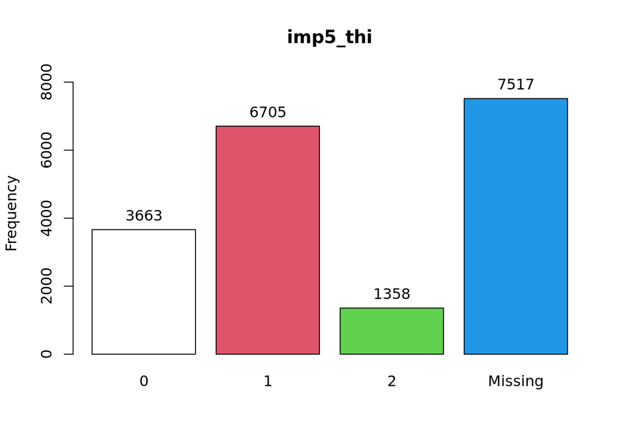

```
##
## Variable: imp5_tas
```

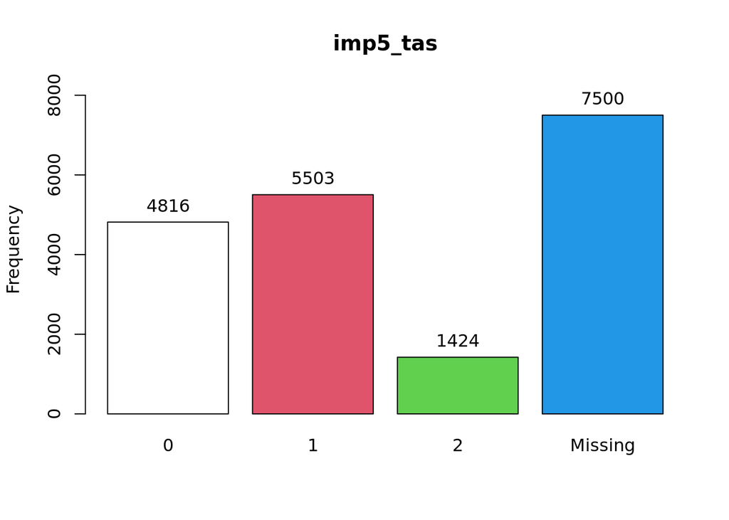

```
##
## Variable: risk5_lie
```

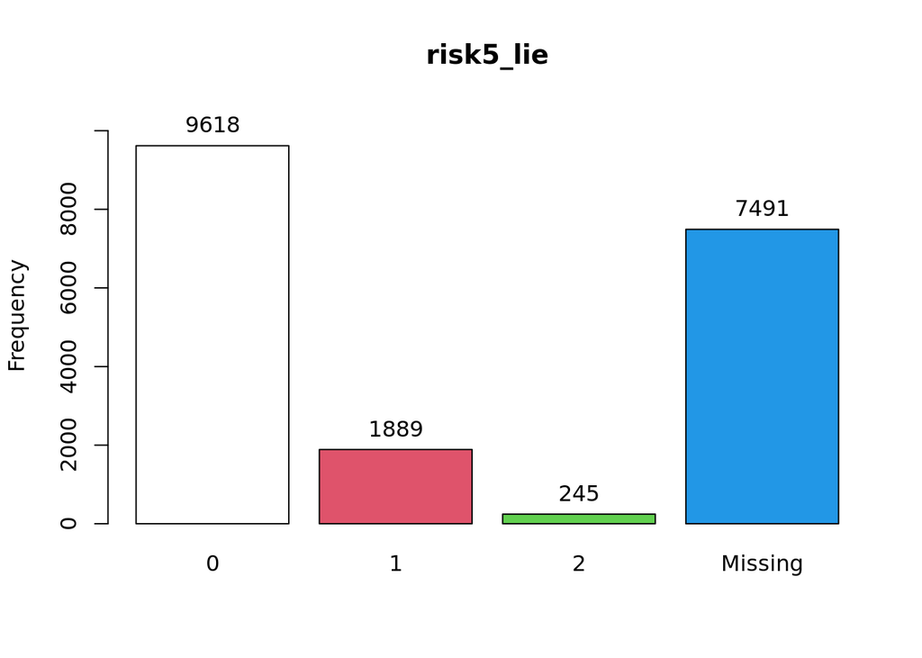

```
##
## Variable: risk5_ste
```

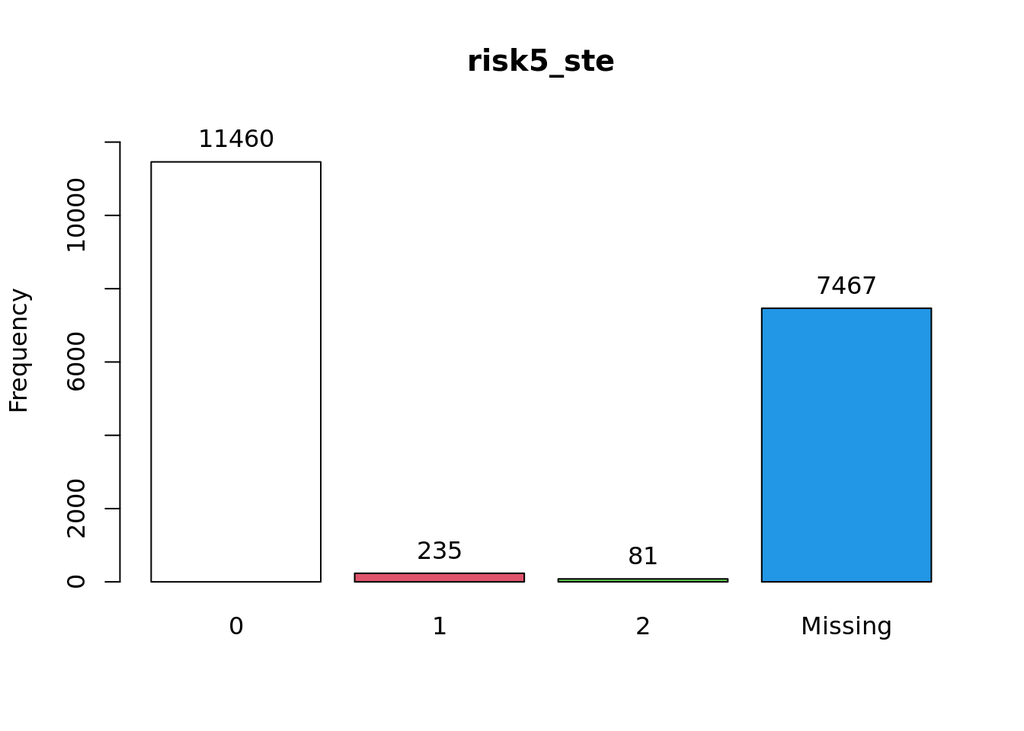

```
##
## Variable: risk5_obe
```

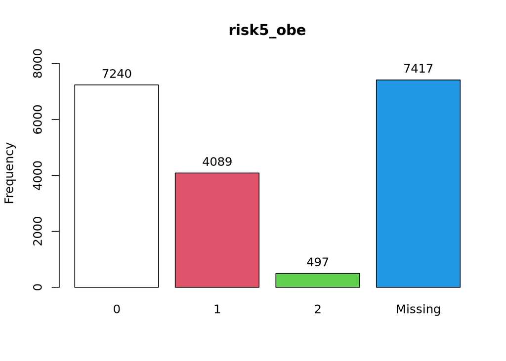

```
##
## Variable: risk5_sch
```

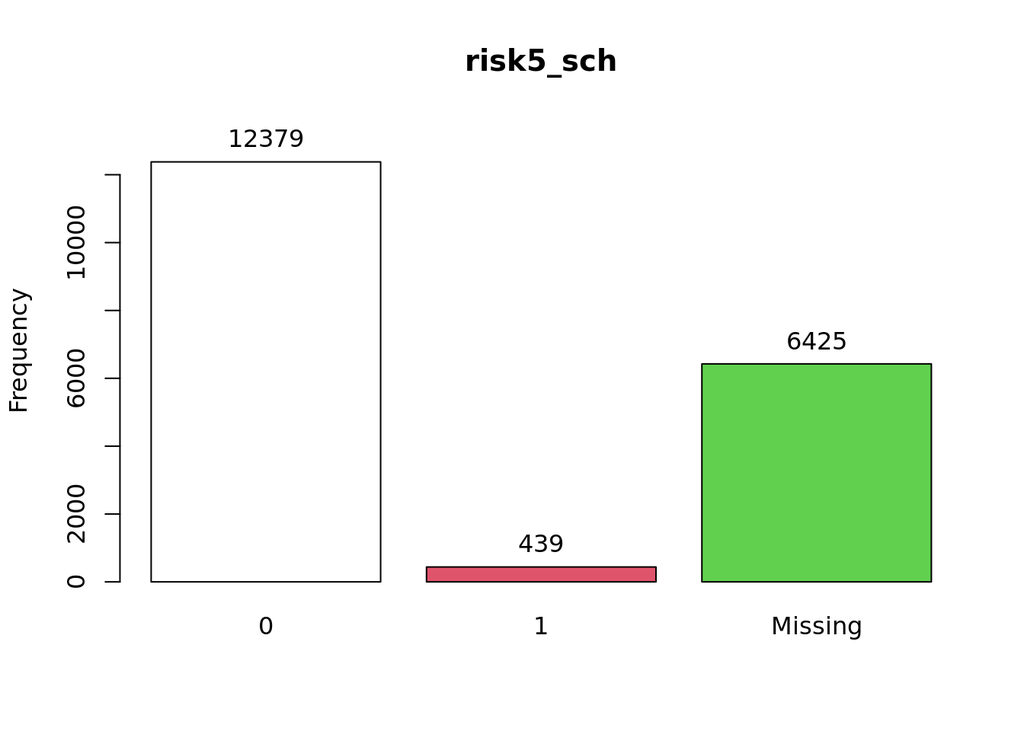

```
##
## Variable: risk5_shl
```

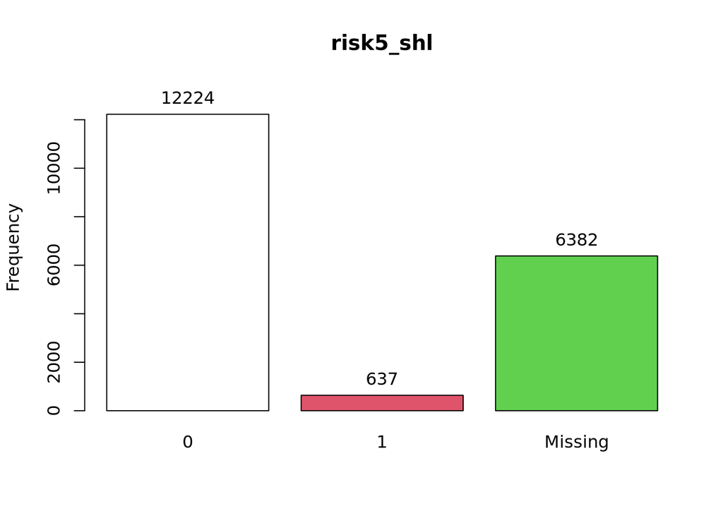

```
##
## Variable: risk5_wpp
```

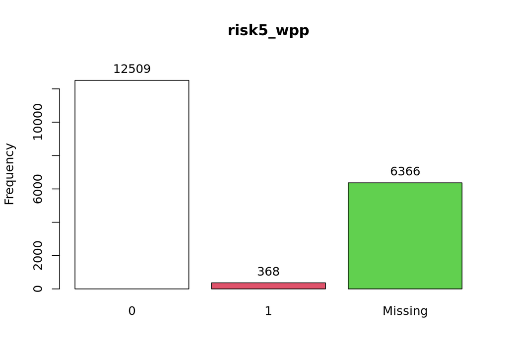

```
##
## Variable: risk5_smk
```

[4 more figures not shown]

```
## [[1]]
## df6[, var_name] :
##         Frequency   %(NA+)   %(NA-)
## 0            6109     31.7     51.7
## 1            4022     20.9     34.1
## 2            1679      8.7     14.2
## <NA>         7433     38.6      0.0
##   Total     19243    100.0    100.0
##
## [[2]]
## df6[, var_name] :
##         Frequency   %(NA+)   %(NA-)
## 0            7116     37.0     60.3
## 1            3277     17.0     27.8
## 2            1414      7.3     12.0
## <NA>         7436     38.6      0.0
##   Total     19243    100.0    100.0
##
## [[3]]
## df6[, var_name] :
##         Frequency   %(NA+)   %(NA-)
## 0            8246     42.9     70.2
## 1            2546     13.2     21.7
## 2             951      4.9      8.1
## <NA>         7500     39.0      0.0
##   Total     19243    100.0    100.0
##
## [[4]]
## df6[, var_name] :
##         Frequency   %(NA+)   %(NA-)
## 0            5342     27.8     45.3
## 1            4690     24.4     39.8
## 2            1755      9.1     14.9
## <NA>         7456     38.7      0.0
##   Total     19243    100.0    100.0
##
## [[5]]
## df6[, var_name] :
##         Frequency   %(NA+)   %(NA-)
## 0            3663     19.0     31.2
```

[output cut: 81 more lines]

```
## [[15]]
## df6[, var_name] :
##         Frequency   %(NA+)   %(NA-)
## 0           10558     54.9     82.2
## 1            2285     11.9     17.8
## <NA>         6400     33.3      0.0
##   Total     19243    100.0    100.0
##
## [[16]]
## df6[, var_name] :
##         Frequency   %(NA+)   %(NA-)
## 0           12485     64.9     97.5
## 1             317      1.6      2.5
## <NA>         6441     33.5      0.0
##   Total     19243    100.0    100.0
```

```r
df6 <- merged_data %>%
  mutate(
    # Self-Control Variables
    imp5_tem = case_when(
      epsdtt00 %in% c(-1, 4) ~ NA_real_,
      epsdtt00 == 1 ~ 0,
      epsdtt00 == 2 ~ 1,
      epsdtt00 == 3 ~ 2
    ),
    imp5_res = case_when(
      epsdro00 %in% c(-1, 4) ~ NA_real_,
      epsdro00 == 1 ~ 0,
      epsdro00 == 2 ~ 1,
      epsdro00 == 3 ~ 2
    ),
    imp5_fid = case_when(
      epsdfs00 %in% c(-1, 4) ~ NA_real_,
      epsdfs00 == 1 ~ 0,
      epsdfs00 == 2 ~ 1,
      epsdfs00 == 3 ~ 2
    ),
    imp5_dis = case_when(
      epsddc00 %in% c(-1, 4) ~ NA_real_,
      epsddc00 == 1 ~ 0,
      epsddc00 == 2 ~ 1,
      epsddc00 == 3 ~ 2
    ),
    imp5_thi = case_when(
      epsdst00 %in% c(-1, 4) ~ NA_real_,
      epsdst00 == 1 ~ 2,
      epsdst00 == 2 ~ 1,
      epsdst00 == 3 ~ 0
    ),
    imp5_tas = case_when(
      epsdte00 %in% c(-1, 4) ~ NA_real_,
      epsdte00 == 1 ~ 2,
      epsdte00 == 2 ~ 1,
      epsdte00 == 3 ~ 0
    ),
    # Risk Taking Variables
    risk5_lie = case_when(
      epsdoa00 %in% c(-1, 4) ~ NA_real_,
      epsdoa00 == 1 ~ 0,
      epsdoa00 == 2 ~ 1,
      epsdoa00 == 3 ~ 2
    ),
    risk5_ste = case_when(
      epsdcs00 %in% c(-1, 4) ~ NA_real_,
      epsdcs00 == 1 ~ 0,
      epsdcs00 == 2 ~ 1,
      epsdcs00 == 3 ~ 2
    ),
    risk5_obe = case_when(
      epsdor00 %in% c(-1, 4) ~ NA_real_,
      epsdor00 == 1 ~ 2,
      epsdor00 == 2 ~ 1,
      epsdor00 == 3 ~ 0
    ),
    risk5_sch = case_when(
      ecq45x00 == -8 ~ NA_real_,
      ecq45x00 == 2 ~ 0,
      ecq45x00 == 1 ~ 1
    ),
    risk5_shl = case_when(
      ecq26x00 == -8 ~ NA_real_,
      ecq26x00 == 2 ~ 0,
      ecq26x00 == 1 ~ 1
    ),
    risk5_wpp = case_when(
      ecq27x00 == -8 ~ NA_real_,
      ecq27x00 == 2 ~ 0,
      ecq27x00 == 1 ~ 1
    ),
    risk5_smk = case_when(
      ecq59x00 == -8 ~ NA_real_,
      ecq59x00 == 2 ~ 0,
      ecq59x00 == 1 ~ 1
    ),
    risk5_drk = case_when(
      ecq61x00 == -8 ~ NA_real_,
      ecq61x00 == 2 ~ 0,
      ecq61x00 == 1 ~ 1
    ),
    risk5_rude = case_when(
      ecq25x00 == -8 ~ NA_real_,
      ecq25x00 == 2 ~ 0,
      ecq25x00 == 1 ~ 1
    ),
    risk5_damg = case_when(
      ecq28x00 == -8 ~ NA_real_,
      ecq28x00 == 2 ~ 0,
      ecq28x00 == 1 ~ 1
    )
  ) %>%
  dplyr::select(imp5_tem, imp5_res, imp5_fid, imp5_dis, imp5_thi, imp5_tas, risk5_lie, risk5_ste, risk5_obe, risk5_sch, risk5_shl, risk5_wpp, risk5_smk, risk5_drk, risk5_rude, risk5_damg) %>%
  labelled::set_variable_labels(
    imp5_tem = "Tempur Tantrums",
    imp5_res = "Restless",
    imp5_fid = "Fidgeting",
    imp5_dis = "Easily Distracted",
    imp5_thi = "Think Before Act (Reverse Scale)",
    imp5_tas = "Sees Task Through to the End (Reverse Scale)",
    risk5_lie = "Lie or Cheat",
    risk5_ste = "Steal",
    risk5_obe = "Generally Obedient (Reverse Scale)",
    risk5_sch = "Miss School",
    risk5_shl = "Shoplifting",
    risk5_wpp = "Write/Paint in Public Places",
    risk5_smk = "Underage Smoking",
    risk5_drk = "Underage Drinking",
    risk5_rude = "Rude or Noisy in Public",
    risk5_damg = "Damage Something That Doesn't Belong to Them"
  )


# Show frequency
self_control5 <- c("imp5_tem", "imp5_res", "imp5_fid", "imp5_dis", "imp5_thi", "imp5_tas","risk5_lie", "risk5_ste", "risk5_obe", "risk5_sch", "risk5_shl", "risk5_wpp", "risk5_smk", "risk5_drk", "risk5_rude", "risk5_damg")


lapply(self_control5, function(var_name) {
  cat("\nVariable:", var_name, "\n")
  tab1(df6[, var_name], main = var_name)
})
```

Now, let’s merge all the self-contorl variables into one data frame:

```r
df_sc <- bind_rows(df4, df5, df6)
# Check dimensions
dim(df_sc)
```

```
## [1] 57729    45
```

Another concept we are interested in is parenting in childhood. In this study, we are especially interested in parents’ behaviors of corrections when their children misbehave. In the following parts, we will look at parenting in wave 5 (age 11) and wave 4 (age 7).

We begin by looking at variables measuring parenting at wave 5 (age 11):

```r
df7 <- merged_data %>%
  mutate(
    par5_plwk = case_when(
      epplwk00 %in% c(-8, -1) ~ NA_real_,
      epplwk00 == 1 ~ 0,
      epplwk00 == 2 ~ 1,
      epplwk00 == 3 ~ 2,
      epplwk00 == 4 ~ 3,
      epplwk00 == 5 ~ 4
    ),
    par5_dibn = case_when(
      epdibn00 %in% c(-1, 6) ~ NA_real_,
      epdibn00 == 1 ~ 0,
      epdibn00 == 2 ~ 1,
      epdibn00 == 3 ~ 2,
      epdibn00 == 4 ~ 3,
      epdibn00 == 5 ~ 4
    ),
    par5_ditr = case_when(
      epditr00 %in% c(-1, 6) ~ NA_real_,
      epditr00 == 1 ~ 0,
      epditr00 == 2 ~ 1,
      epditr00 == 3 ~ 2,
      epditr00 == 4 ~ 3,
      epditr00 == 5 ~ 4
    ),
    par5_dire = case_when(
      epdire00 %in% c(-1, 6) ~ NA_real_,
      epdire00 == 1 ~ 0,
      epdire00 == 2 ~ 1,
      epdire00 == 3 ~ 2,
      epdire00 == 4 ~ 3,
      epdire00 == 5 ~ 4
    )
  ) %>%
  dplyr::select(par5_plwk, par5_dibn, par5_ditr, par5_dire) %>%
  labelled::set_variable_labels(
  par5_plwk = "Unsupervised hours with friends",
  par5_dibn = "Send to bedrooms when misbehaves",
  par5_ditr = "Take away treats when misbehaves",
  par5_dire = "Try to reason with her when misbehaves"
)

# Show frequency
parenting5 <- c("par5_plwk", "par5_dibn", "par5_ditr", "par5_dire")

lapply(parenting5, function(var_name) {
  cat("\nVariable:", var_name, "\n")
  print(summary(df7[[var_name]]))
  tab1(df7[, var_name], main = var_name)
})
```

```
##
## Variable: par5_plwk
##    Min. 1st Qu.  Median    Mean 3rd Qu.    Max.    NA's
##   0.000   0.000   2.000   1.961   4.000   4.000    7072
```

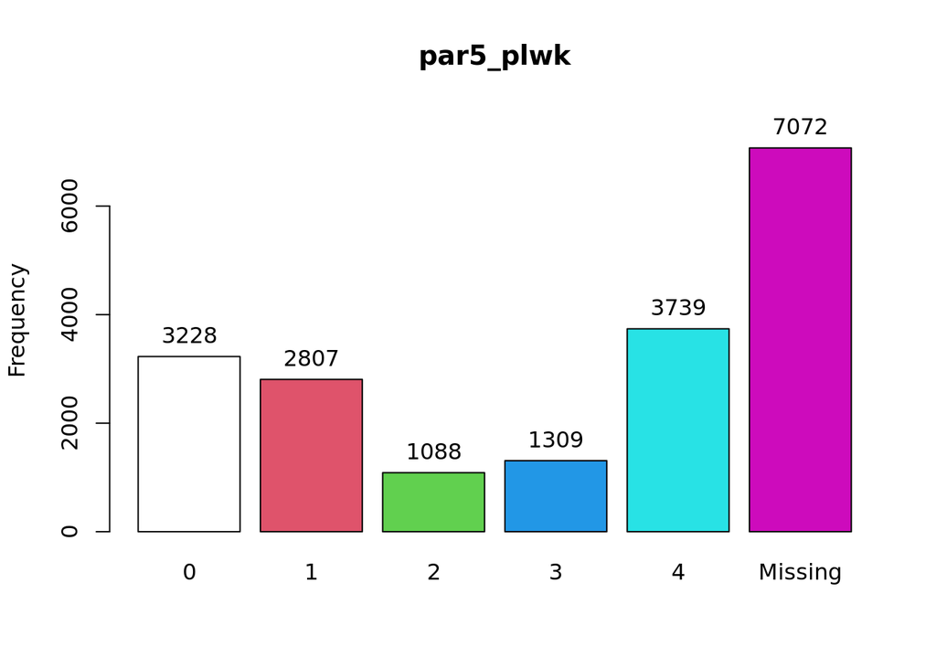

```
##
## Variable: par5_dibn
##    Min. 1st Qu.  Median    Mean 3rd Qu.    Max.    NA's
##   0.000   1.000   1.000   1.403   2.000   4.000    7742
```

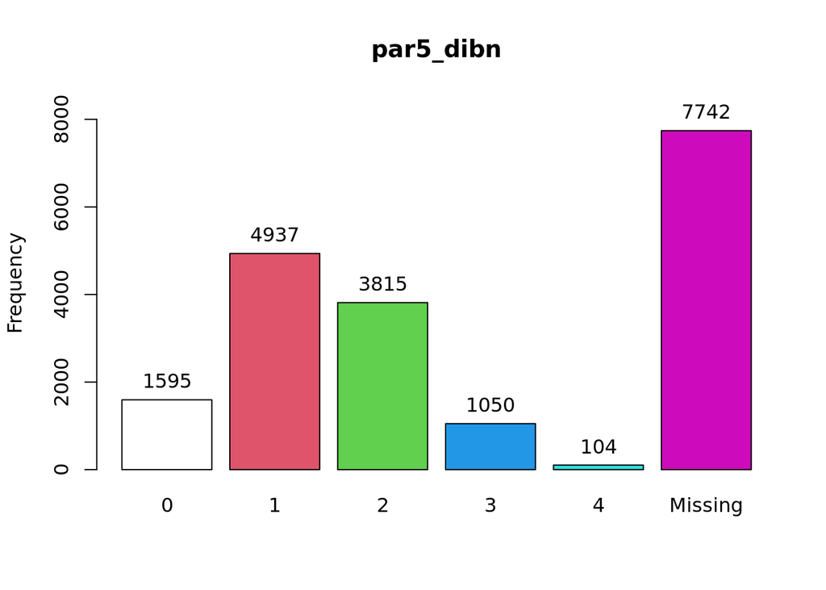

```
##
## Variable: par5_ditr
##    Min. 1st Qu.  Median    Mean 3rd Qu.    Max.    NA's
##   0.000   1.000   1.000   1.425   2.000   4.000    7748
```

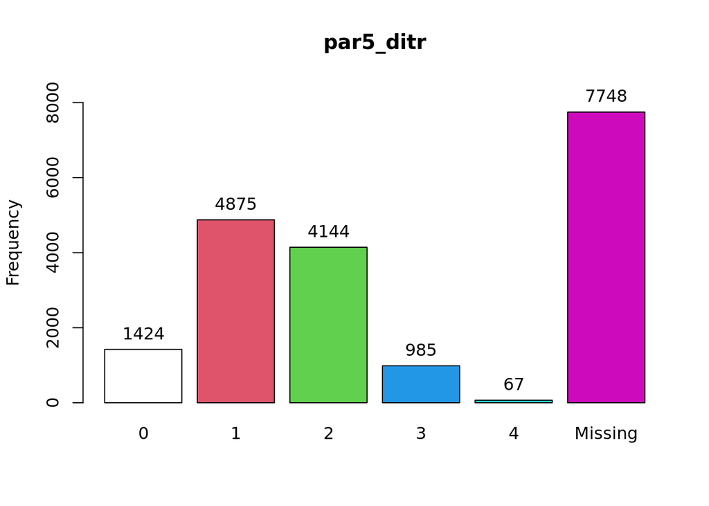

```
##
## Variable: par5_dire
##    Min. 1st Qu.  Median    Mean 3rd Qu.    Max.    NA's
##   0.000   1.000   2.000   2.165   3.000   4.000    7892
```

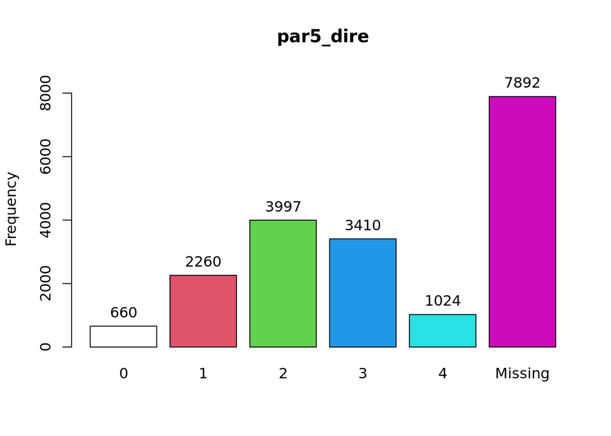

```
## [[1]]
## df7[, var_name] :
##         Frequency   %(NA+)   %(NA-)
## 0            3228     16.8     26.5
## 1            2807     14.6     23.1
## 2            1088      5.7      8.9
## 3            1309      6.8     10.8
## 4            3739     19.4     30.7
## <NA>         7072     36.8      0.0
##   Total     19243    100.0    100.0
##
## [[2]]
## df7[, var_name] :
##         Frequency   %(NA+)   %(NA-)
## 0            1595      8.3     13.9
## 1            4937     25.7     42.9
## 2            3815     19.8     33.2
## 3            1050      5.5      9.1
## 4             104      0.5      0.9
## <NA>         7742     40.2      0.0
##   Total     19243    100.0    100.0
##
## [[3]]
## df7[, var_name] :
##         Frequency   %(NA+)   %(NA-)
## 0            1424      7.4     12.4
## 1            4875     25.3     42.4
## 2            4144     21.5     36.1
## 3             985      5.1      8.6
## 4              67      0.3      0.6
## <NA>         7748     40.3      0.0
##   Total     19243    100.0    100.0
##
## [[4]]
## df7[, var_name] :
##         Frequency   %(NA+)   %(NA-)
## 0             660      3.4      5.8
## 1            2260     11.7     19.9
## 2            3997     20.8     35.2
## 3            3410     17.7     30.0
## 4            1024      5.3      9.0
## <NA>         7892     41.0      0.0
##   Total     19243    100.0    100.0
```

Now, we do the same for wave 4 (age 7)

```r
df8 <- merged_data %>%
  mutate(
    # Send to bedrooms when misbehaves
    par4_dibn = case_when(
      dmdibna0 %in% c(-9, -8, -1, 6) ~ NA_real_,
      dmdibna0 == 1 ~ 0,
      dmdibna0 == 2 ~ 1,
      dmdibna0 == 3 ~ 2,
      dmdibna0 == 4 ~ 3,
      dmdibna0 == 5 ~ 4
    ),
    # Take away treats when misbehaves
    par4_ditr = case_when(
      dmditra0 %in% c(-9, -8, -1, 6) ~ NA_real_,
      dmditra0 == 1 ~ 0,
      dmditra0 == 2 ~ 1,
      dmditra0 == 3 ~ 2,
      dmditra0 == 4 ~ 3,
      dmditra0 == 5 ~ 4
    ),
    # Try to reason with her when misbehaves
    par4_dire = case_when(
      dmdirea0 %in% c(-9, -8, -1, 6) ~ NA_real_,
      dmdirea0 == 1 ~ 0,
      dmdirea0 == 2 ~ 1,
      dmdirea0 == 3 ~ 2,
      dmdirea0 == 4 ~ 3,
      dmdirea0 == 5 ~ 4
    )
  ) %>% dplyr::select(par4_dibn, par4_ditr, par4_dire) %>%
  labelled::set_variable_labels(
  par4_dibn = "Send to bedrooms when misbehaves",
  par4_ditr = "Take away treats when misbehaves",
  par4_dire = "Try to reason with her when misbehaves"
)

# Display summary for each variable
parenting4 <- c("par4_dibn", "par4_ditr", "par4_dire")

lapply(parenting4, function(var_name) {
  cat("\nVariable:", var_name, "\n")
  print(summary(df8[[var_name]]))
  tab1(df8[, var_name], main = var_name)
})
```

```
##
## Variable: par4_dibn
##    Min. 1st Qu.  Median    Mean 3rd Qu.    Max.    NA's
##   0.000   1.000   2.000   1.661   2.000   4.000    6096
```

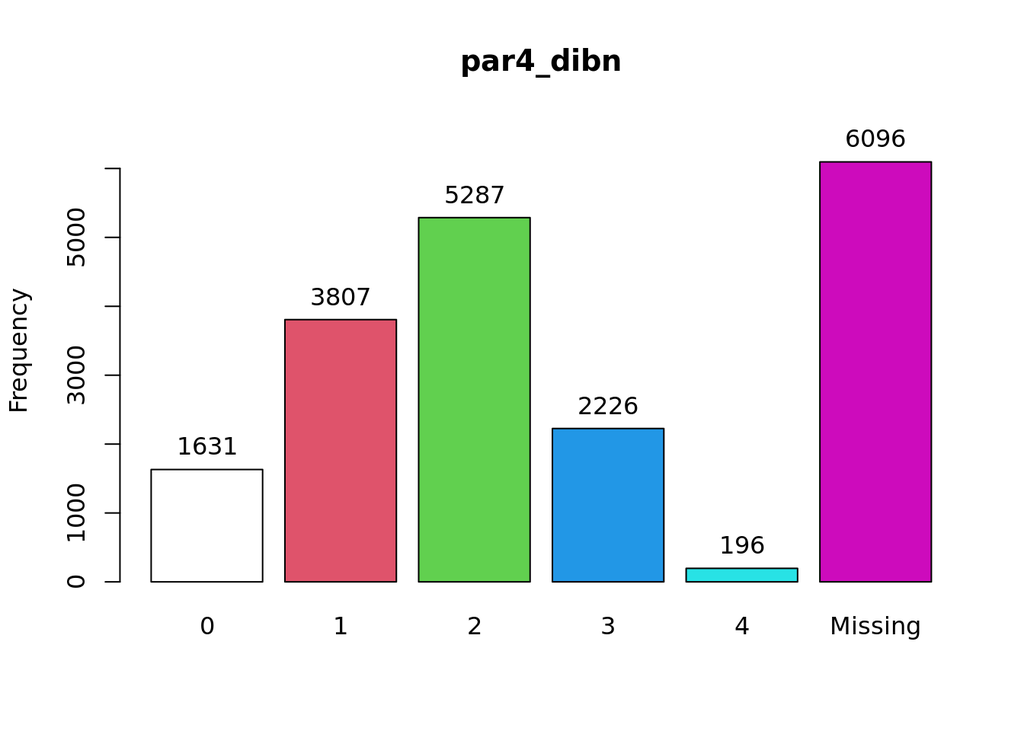

```
##
## Variable: par4_ditr
##    Min. 1st Qu.  Median    Mean 3rd Qu.    Max.    NA's
##   0.000   1.000   2.000   1.715   2.000   4.000    6130
```

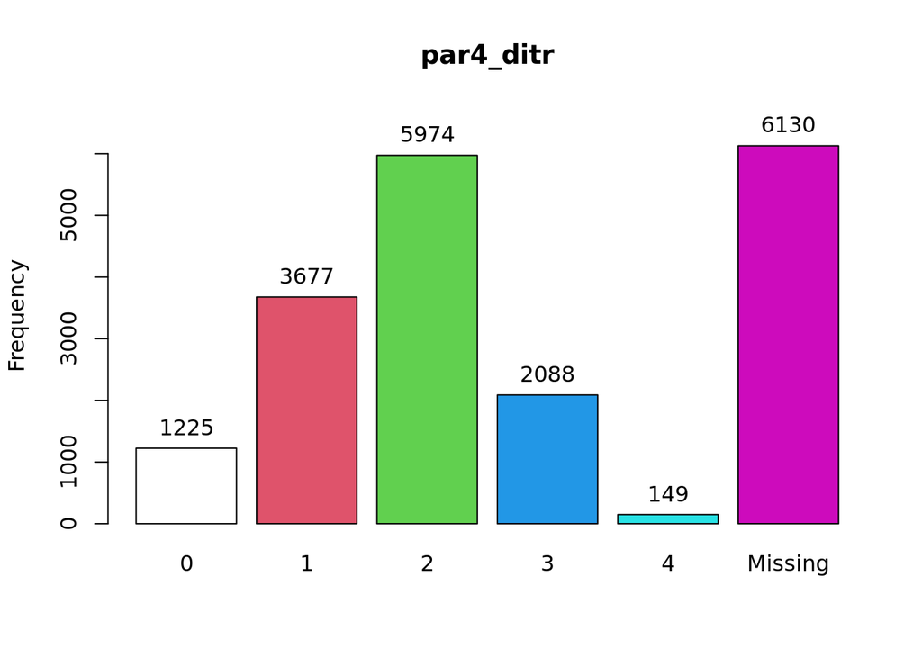

```
##
## Variable: par4_dire
##    Min. 1st Qu.  Median    Mean 3rd Qu.    Max.    NA's
##   0.000   2.000   3.000   2.535   3.000   4.000    6182
```

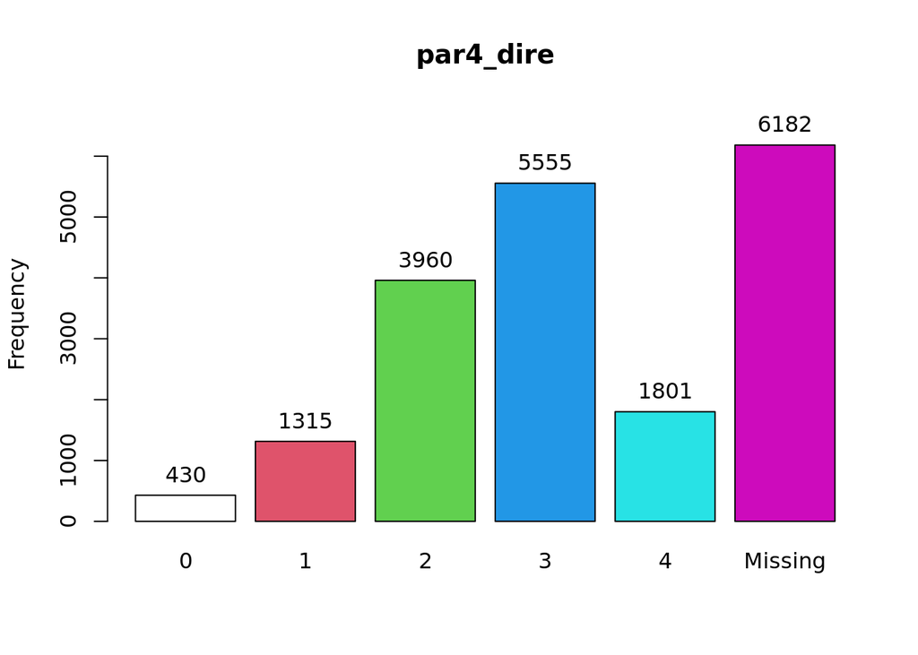

```
## [[1]]
## df8[, var_name] :
##         Frequency   %(NA+)   %(NA-)
## 0            1631      8.5     12.4
## 1            3807     19.8     29.0
## 2            5287     27.5     40.2
## 3            2226     11.6     16.9
## 4             196      1.0      1.5
## <NA>         6096     31.7      0.0
##   Total     19243    100.0    100.0
##
## [[2]]
## df8[, var_name] :
##         Frequency   %(NA+)   %(NA-)
## 0            1225      6.4      9.3
## 1            3677     19.1     28.0
## 2            5974     31.0     45.6
## 3            2088     10.9     15.9
## 4             149      0.8      1.1
## <NA>         6130     31.9      0.0
##   Total     19243    100.0    100.0
##
## [[3]]
## df8[, var_name] :
##         Frequency   %(NA+)   %(NA-)
## 0             430      2.2      3.3
## 1            1315      6.8     10.1
## 2            3960     20.6     30.3
## 3            5555     28.9     42.5
## 4            1801      9.4     13.8
## <NA>         6182     32.1      0.0
##   Total     19243    100.0    100.0
```

Now, we can combine all parenting variables into one data frame:

```r
df_pa <- bind_rows(df7, df8)
# Check dimensions
dim(df_pa)
```

```
## [1] 38486     7
```

Finally, let’s look at and recode the potential covariates:

```r
df_co <- merged_data %>%
  mutate(
    pared = case_when(
      fdacaq00 == 96 ~ 0,
      fdacaq00 == 95 | fdacaq00 == -1 ~ NA_real_,
      TRUE ~ fdacaq00
    ),

    race = case_when(
      fd06e00 %in% c(-9, -1) ~ NA_real_,
      fd06e00 == 1 ~ 1,
      fd06e00 == 2 ~ 4,
      fd06e00 %in% c(3, 4) ~ 2,
      fd06e00 == 5 ~ 3,
      fd06e00 == 6 ~ 4
    ),

    gender6 = case_when(
      fccsex00 == 2 ~ 0,
      TRUE ~ 1
    ),

    married = case_when(
      amfcin00 %in% c(-9, -8, -1) ~ NA_real_,
      amfcin00 %in% c(1, 4, 5, 6) ~ 0,
      amfcin00 %in% c(2, 3) ~ 1
    )
  ) %>%
  labelled::set_variable_labels(
    pared = "Highest Parent's Education",
    race = "Racial Categories",
    gender6 = "Gender of CM",
    married = "Marital Status at 9 month-old"
  ) %>%
  mutate(
    race = factor(race, levels = c(1, 2, 3, 4), labels = c("White British", "Asian British", "Black British", "Other British")),
    gender = factor(gender6, levels = c(0, 1), labels = c("Female", "Male"))
  ) %>%
  dplyr::select(pared, race, gender, married)

# Show frequency
covar <- c("pared", "race", "gender", "married")

lapply(covar, function(var_name) {
  cat("\nVariable:", var_name, "\n")
  print(summary(df_co[[var_name]]))
  tab1(df_co[, var_name], main = var_name)

})
```

```
##
## Variable: pared
##    Min. 1st Qu.  Median    Mean 3rd Qu.    Max.    NA's
##   0.000   2.000   3.000   2.883   4.000   5.000    8379
```

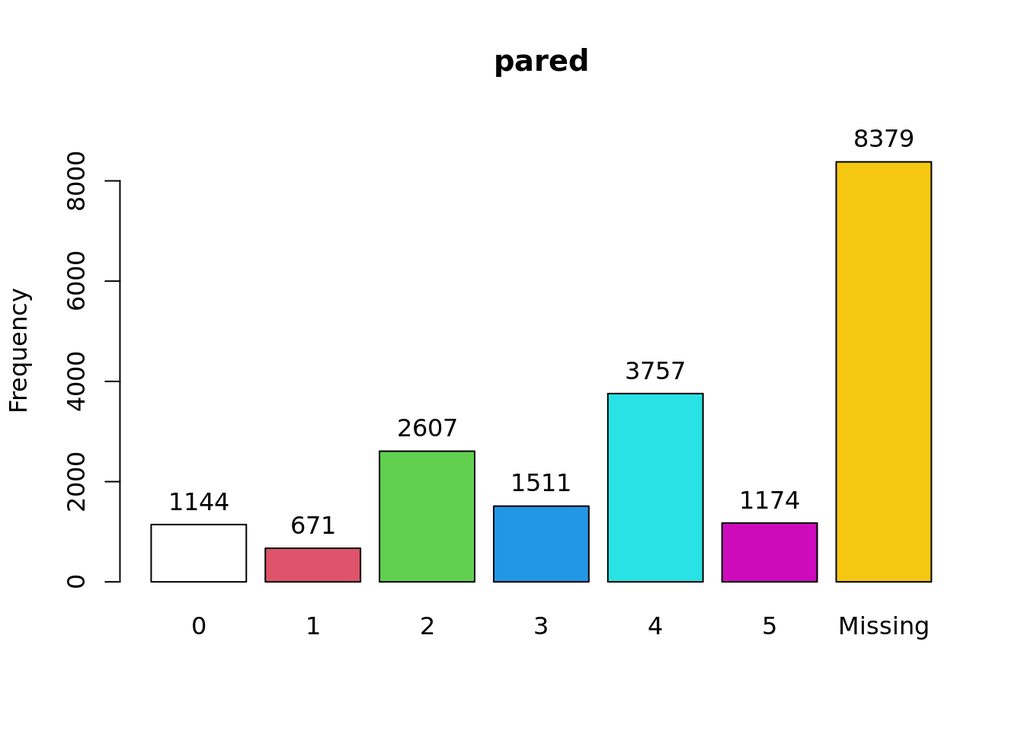

```
##
## Variable: race
## White British Asian British Black British Other British          NA's
##          9319          1187           383           328          8026
```

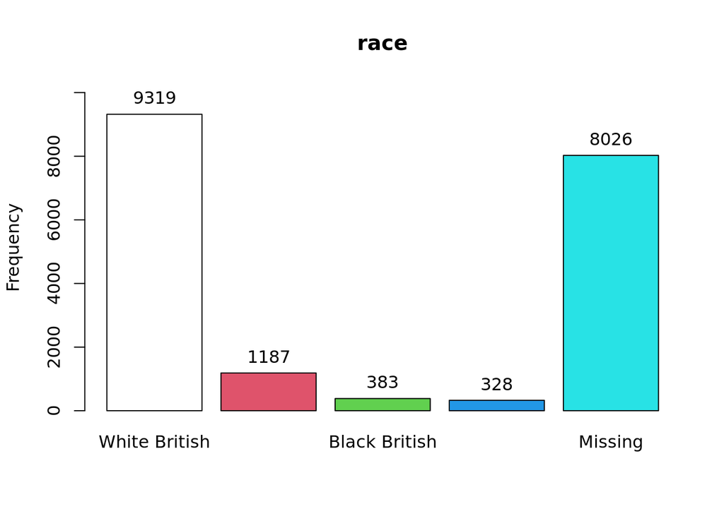

```
##
## Variable: gender
## Female   Male
##   5842  13401
```

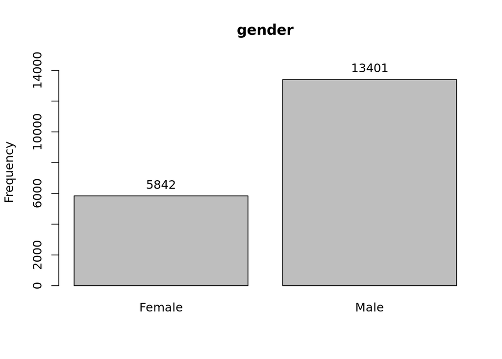

```
##
## Variable: married
##    Min. 1st Qu.  Median    Mean 3rd Qu.    Max.    NA's
##  0.0000  0.0000  1.0000  0.5948  1.0000  1.0000     711
```

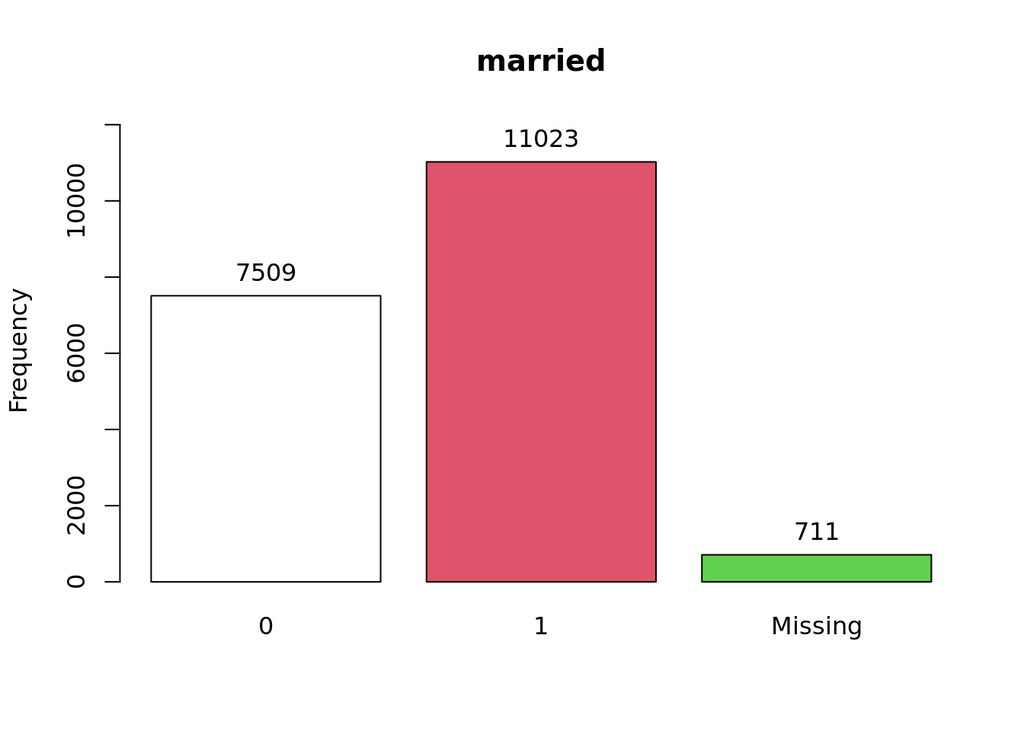

```
## [[1]]
## df_co[, var_name] :
##         Frequency   %(NA+)   %(NA-)
## 0            1144      5.9     10.5
## 1             671      3.5      6.2
## 2            2607     13.5     24.0
## 3            1511      7.9     13.9
## 4            3757     19.5     34.6
## 5            1174      6.1     10.8
## <NA>         8379     43.5      0.0
##   Total     19243    100.0    100.0
##
## [[2]]
## df_co[, var_name] :
##               Frequency   %(NA+)   %(NA-)
## White British      9319     48.4     83.1
## Asian British      1187      6.2     10.6
## Black British       383      2.0      3.4
## Other British       328      1.7      2.9
## <NA>               8026     41.7      0.0
##   Total           19243    100.0    100.0
##
## [[3]]
## df_co[, var_name] :
##         Frequency Percent Cum. percent
## Female       5842    30.4         30.4
## Male        13401    69.6        100.0
##   Total     19243   100.0        100.0
##
## [[4]]
## df_co[, var_name] :
##         Frequency   %(NA+)   %(NA-)
## 0            7509     39.0     40.5
## 1           11023     57.3     59.5
## <NA>          711      3.7      0.0
##   Total     19243    100.0    100.0
```

Finally, let’s combine all the relevant columns into one data frame:

```r
df_re <- bind_rows(df_aggr, df_sc, df_co, df_pa)
# Check dimensions
dim(df_re)
```

```
## [1] 173187     68
```

```r
# Write it to r data file (uncomment when needed)
## saveRDS(df_re, file = "/home/freeyang/research_data/mcs/merging/relevant_columns.rds")
```

## Potential Issues of Data

From the above analysis we identified the following potential issues with our dataset:

1. **Lots of missing cases**

This is not uncommon when working with panel data. Most variables in wave 7 (age 17) have about 40%-50% missing. The missing cases are very likely to be related to attrition. However, we suggest careful missing value analysis before proceeding.

2. **Sample Unbalance**

Another critical issue we identified from the above sections is the data unbalance issue. Most variables we plan to use are highly unbalanced. Specifically, most variables measuring adolescent aggressive behaviors are extremely unbalance. Some of the variables measuring adolescent aggressive behaviors only have about 2% positive cases. Unbalanced endogenous variables require special treatment in conventional SEM. How extremely unbalanced endogenous variables affect tree-based SEM also requires further attention.